# Randbereichs-Trends motorischer Testleistungen nach Kreis und Erhebungswelle

zeitlich

räumlich

Kreisebene

20-Meter-Sprint

6-Minuten-Lauf

Standweitsprung

Einbeinstand

Medizinballstoßen

Sternlauf

Autor:innen

Zugehörigkeit

Toni Wöhrl

Universität Erfurt

Florian Bähr

Universität Erfurt

Veröffentlichungsdatum

Geändert

17. September 2026

## Einleitung

Dieser Beitrag untersucht Unterschiede zwischen Landkreisen bzw. kreisfreien Städten (im Folgenden *Kreise*) und Entwicklungen über Erhebungswellen hinweg im *Anteil von Kindern mit besonders hohen oder besonders niedrigen motorischen Testleistungen*.

Für jede Testaufgabe (6-Minuten-Lauf, Sternlauf, 20-Meter-Sprint, Medizinballstoßen, Standweitsprung, Einbeinstand) werden alters-, geschlechts- und jahresspezifische Referenzschwellen für ganz Thüringen berechnet. Anschließend wird für jede Kombination aus Kreis und Erhebungsjahr der beobachtete Anteil im jeweiligen Randbereich dem typischen Kreiswert desselben Jahrgangs gegenübergestellt.

Ziel ist die deskriptive Identifikation von Kreisen mit vergleichsweise vielen oder wenigen leistungsstarken beziehungsweise auffälligen Kindern. Die Auswertungen sind ein Ausgangspunkt für vertiefende Analysen und keine abschließende Bewertung einzelner Kreise.

## Methodik

**HinweisReferenzschwellen**

Für jede motorische Testaufgabe werden alters- und geschlechtsspezifische Referenzschwellen getrennt für jeden Erhebungsjahrgang berechnet. Die Altersgruppen werden anhand des Alters in Monaten gebildet und umfassen die Bereiche 0 bis unter 100 Monate, 100 bis unter 105 Monate, 105 bis unter 109 Monate, 109 Monate und älter. Innerhalb jeder Kombination aus Erhebungsjahr, Geschlecht, Altersgruppe und Testaufgabe werden das 20. und das 80. Rohwertperzentil der in ganz Thüringen beobachteten Werte bestimmt.

Ein Kind wird dem unteren Randbereich zugeordnet, wenn sein Wert unterhalb des 20. Rohwertperzentils liegt. Dem oberen Randbereich wird es zugeordnet, wenn sein Wert oberhalb des 80. Rohwertperzentils liegt. Werte genau auf der jeweiligen Schwelle werden keinem Randbereich zugerechnet. Deshalb können die beobachteten Anteile von den nominellen 20 Prozent abweichen, insbesondere bei vielen gleichen Messwerten.

**HinweisLeistungseinordnung**

Die Rohwertperzentile werden abhängig von der Messrichtung interpretiert. Bei Testleistungen, bei denen höhere Werte günstig sind, kennzeichnet der obere Randbereich oberhalb des 80. Rohwertperzentils leistungsstarke Kinder. Bei zeitbasierten Testleistungen, bei denen kürzere Zeiten günstig sind, kennzeichnet dagegen der untere Randbereich unterhalb des 20. Rohwertperzentils leistungsstarke Kinder.

Bei 6-Minuten-Lauf, Standweitsprung, Medizinballstoßen und Einbeinstand stehen höhere Werte für bessere Leistungen. Hier gilt der obere Randbereich als leistungsstark und der untere Randbereich als auffällig.

Beim 20-Meter-Sprint und Sternlauf stehen niedrigere Zeiten für bessere Leistungen. Hier gilt daher der untere Randbereich als leistungsstark und der obere Randbereich als auffällig.

Die Einordnung wird in allen Tabellen und Abbildungen berücksichtigt. Blau steht immer für eine günstige Abweichung (z. B. verhältnismäßig viele Leistungsstarke oder wenige Auffällige) und Rot immer für eine ungünstige Abweichung.

**HinweisKreisanteile und typischer Kreiswert**

Für jede Kombination aus Kreis, Erhebungsjahr und Testleistung werden die Anzahl gültiger Messwerte, die Anzahl der Kinder im jeweiligen Randbereich und deren Anteil berechnet.

Als Vergleichswert dient der **typische Kreiswert** des jeweiligen Erhebungsjahrgangs. Dieser Wert entspricht hier dem Median der Randbereichsanteile aller Kreise eines Jahrgangs. Damit liegen jeweils etwa die Hälfte der Kreisanteile unterhalb und die andere Hälfte oberhalb des typischen Kreiswerts.

Der typische Kreiswert ist nicht zwingend genau 20 Prozent. Gründe sind unter anderem gleiche Messwerte an den Perzentilgrenzen, unterschiedliche Stichprobenzusammensetzungen der Kreise sowie fehlende Messwerte.

**HinweisProzentpunkte**

Die Abbildungen zeigen die *Differenz zwischen dem beobachteten Kreisanteil und dem typischen Kreiswert des gleichen Erhebungsjahrgangs in Prozentpunkten*.

**Beispiel:** Liegt der Anteil leistungsstarker Kinder in einem Kreis bei 24 Prozent und der typische Kreiswert des Jahrgangs bei 20 Prozent, beträgt die Abweichung plus 4 Prozentpunkte. Dies ist nicht dasselbe wie ein Anstieg um 4 Prozent.

**HinweisToleranzzone und Unsicherheitsbalken**

Die vertikalen Unsicherheitsbalken zeigen für jeden Kreisanteil einen fallzahlabhängigen näherungsweisen 95-Prozent-Bereich auf Grundlage des binomialen Standardfehlers. **Grau** markierte Punkte haben einen Unsicherheitsbalken, der die Nulllinie einschließt. **Blau** bzw. **rot** markierte Punkte liegen mit ihrem gesamten Unsicherheitsbalken auf der günstigen bzw. ungünstigen Seite der Nulllinie.

Bei kleineren Zahlen gültiger Messwerte sind die Unsicherheitsbalken länger, bei größeren Zahlen gültiger Messwerte kürzer. Sie berücksichtigen damit, dass Anteile aus kleinen Stichproben stärker zufällig schwanken als Anteile aus großen Stichproben.

Die Unsicherheitsbalken dienen der deskriptiven Einordnung. Sie berücksichtigen die Zahl gültiger Messwerte, nicht jedoch mögliche Abhängigkeiten zwischen Kindern innerhalb von Schulen oder Klassen, Unterschiede der Stichprobenzusammensetzung zwischen Kreisen oder die Unsicherheit des Median-Vergleichswerts (typischer Kreis).

**HinweisDeskriptive Ergebnisse**

Die Ergebnisse sind deskriptiv. Sie erlauben keine kausalen Aussagen über Kreise oder Ursachen möglicher Unterschiede. Unterschiede können unter anderem mit der Zusammensetzung der Stichprobe, der Abdeckung einzelner Schulen, Messbedingungen, fehlenden Werten oder zufälligen Schwankungen zusammenhängen.

**HinweisDatenauswahl**

Die Ausdauerzeit beim Einbeinstand wird bei 60 Sekunden gedeckelt. Beim Sternlauf und beim 20-Meter-Sprint stehen kürzere Zeiten für bessere Leistungen.

## Randbereichs-Zusammenfassung

## Referenzschwellen

Die folgende ausklappbare Tabelle enthält die alters-, geschlechts- und jahrgangsspezifischen Referenzwerte. Sie kann durchsucht, sortiert und nach Spalten gefiltert werden.

**HinweisReferenzschwellen nach Jahrgang, Geschlecht und Altersgruppe**

| Erhebungswelle | Testleistung | Geschlecht | Altersgruppe | Anzahl gültiger Referenzwerte | 20. Rohwertperzentil | 80. Rohwertperzentil |
| --- | --- | --- | --- | --- | --- | --- |
| 2022 | 6-Minuten-Lauf | männl. | 0–<100 | 1328 | 864 | 1098 |
| 2022 | 6-Minuten-Lauf | männl. | 100–<105 | 1752 | 864 | 1098 |
| 2022 | 6-Minuten-Lauf | männl. | 105–<109 | 1371 | 864 | 1107 |
| 2022 | 6-Minuten-Lauf | männl. | 109+ | 780 | 826.8 | 1080 |
| 2022 | 6-Minuten-Lauf | weibl. | 0–<100 | 1491 | 810 | 1008 |
| 2022 | 6-Minuten-Lauf | weibl. | 100–<105 | 1864 | 823.8 | 1026 |
| 2022 | 6-Minuten-Lauf | weibl. | 105–<109 | 1338 | 819 | 1026 |
| 2022 | 6-Minuten-Lauf | weibl. | 109+ | 547 | 774 | 988.2 |
| 2022 | 20-Meter-Sprint | männl. | 0–<100 | 1354 | 4.1 | 4.8 |
| 2022 | 20-Meter-Sprint | männl. | 100–<105 | 1776 | 4.1 | 4.7 |

[output cut: 182 more lines]

## Kreiswerte

Die folgende aufklappbare Tabelle zeigt die Anzahl gültiger Messwerte, die Anzahl der Kinder im jeweiligen Randbereich, den beobachteten Kreisanteil und den typischen Kreiswert des entsprechenden Erhebungsjahres. Die Abweichung ist in Prozentpunkten angegeben.

**HinweisKreiswerte**

| Erhebungswelle | Kreis | Testleistung | Kategorie | Randbereich | Anzahl gültiger Messwerte | Anzahl Kinder im Randbereich | Anteil im Randbereich in Prozent | Typischer Kreiswert in Prozent | Abweichung in Prozentpunkten | Unsicherheit | Einordnung |
| --- | --- | --- | --- | --- | --- | --- | --- | --- | --- | --- | --- |
| 2022 | Altenburger Land | 6-Minuten-Lauf | Auffällige Kinder | Unterhalb des 20. Perzentils | 410 | 130 | 31.7073170731707 | 17.3532668881506 | 14.3540501850201 | 1.94577173860995 | Mehr auffällige Kinder als erwartet |
| 2022 | Eichsfeld | 6-Minuten-Lauf | Auffällige Kinder | Unterhalb des 20. Perzentils | 691 | 114 | 16.4978292329957 | 17.3532668881506 | -0.855437655154947 | 1.4988038357009 | Innerhalb der Toleranzzone |
| 2022 | Erfurt-Stadt | 6-Minuten-Lauf | Auffällige Kinder | Unterhalb des 20. Perzentils | 712 | 184 | 25.8426966292135 | 17.3532668881506 | 8.48942974106287 | 1.47653526085249 | Mehr auffällige Kinder als erwartet |
| 2022 | Gera-Stadt | 6-Minuten-Lauf | Auffällige Kinder | Unterhalb des 20. Perzentils | 301 | 50 | 16.6112956810631 | 17.3532668881506 | -0.741971207087484 | 2.27091339366306 | Innerhalb der Toleranzzone |
| 2022 | Gotha | 6-Minuten-Lauf | Auffällige Kinder | Unterhalb des 20. Perzentils | 772 | 224 | 29.0155440414508 | 17.3532668881506 | 11.6622771533002 | 1.41799653423769 | Mehr auffällige Kinder als erwartet |
| 2022 | Greiz | 6-Minuten-Lauf | Auffällige Kinder | Unterhalb des 20. Perzentils | 466 | 57 | 12.2317596566524 | 17.3532668881506 | -5.12150723149825 | 1.82511763398707 | Weniger auffällige Kinder als erwartet |
| 2022 | Hildburghausen | 6-Minuten-Lauf | Auffällige Kinder | Unterhalb des 20. Perzentils | 407 | 42 | 10.3194103194103 | 17.3532668881506 | -7.03385656874029 | 1.95292972135528 | Weniger auffällige Kinder als erwartet |
| 2022 | Ilm-Kreis | 6-Minuten-Lauf | Auffällige Kinder | Unterhalb des 20. Perzentils | 533 | 80 | 15.0093808630394 | 17.3532668881506 | -2.34388602511121 | 1.70655470708883 | Innerhalb der Toleranzzone |
| 2022 | Jena-Stadt | 6-Minuten-Lauf | Auffällige Kinder | Unterhalb des 20. Perzentils | 653 | 52 | 7.96324655436447 | 17.3532668881506 | -9.39002033378614 | 1.54179711578518 | Weniger auffällige Kinder als erwartet |
| 2022 | Kyffhäuserkreis | 6-Minuten-Lauf | Auffällige Kinder | Unterhalb des 20. Perzentils | 420 | 76 | 18.0952380952381 | 17.3532668881506 | 0.741971207087488 | 1.92246824241341 | Innerhalb der Toleranzzone |

[output cut: 1046 more lines]

## Abbildungen

**HinweisLeistungsstarke**

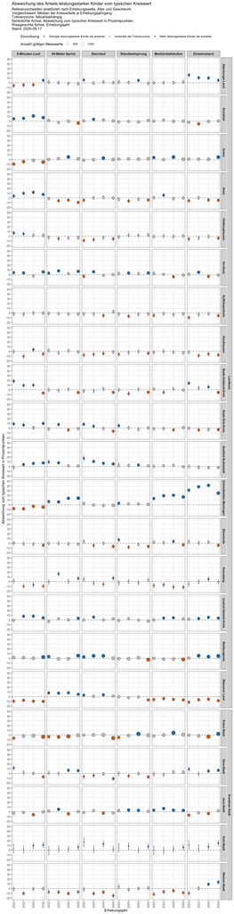

**HinweisAuffällige**

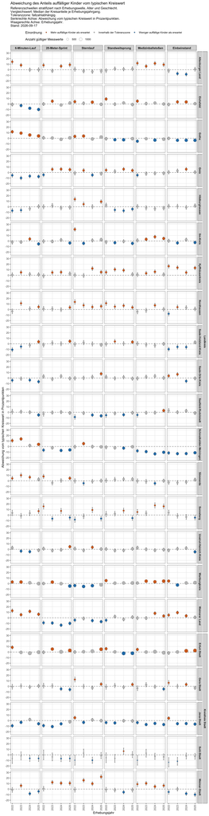

## Sonstiges

**HinweisAktualisierungen**

- 2026-09-17: Schätzung der Unsicherheiten über binomialen Standardfehler
- 2026-09-16: Veröffentlichung

**HinweisKI-Hinweis:**

Auswahl, Inhalte und Schlussredaktion menschlich; Entwurfshilfen KI. Verwendetes System: Perplexity AI, generatives KI-Sprachmodell; konkretes zugrunde liegendes Modell nicht ausgewiesen.